# Analysis for Choice Task (words version)

Xinyue Li

8/3/2021

## Distribution plots of delta value and delta memorability

These two plots show the distribution of delta memorability (memorability for more memorable item - less memorable item) and the distribution of delta value (value for more memorable item - value for less memorable item), for all choice pairs among participants.

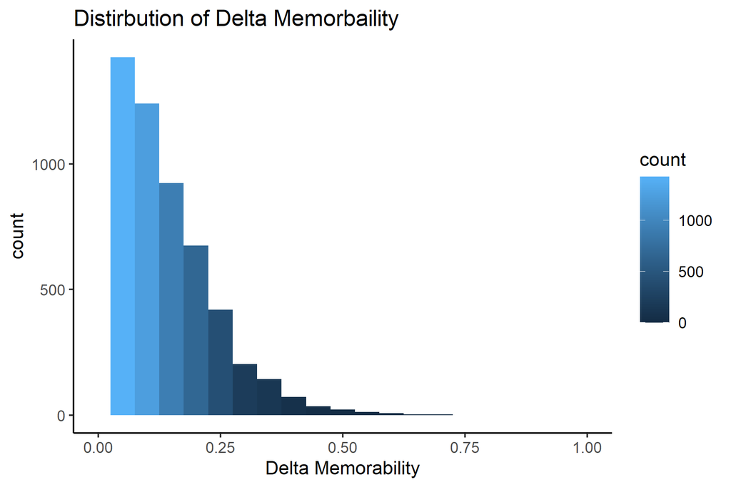

```r
#plot abs delta mem
g.deltaMem = choice %>% ggplot(aes(x = abs.mem, fill=..count..))+
  geom_histogram(binwidth = 0.05)+
  theme_classic()+
  xlim(0,1)+
  ggtitle('Distirbution of Delta Memorbaility')+
  xlab('Delta Memorability')

ggsave('g.deltaMem.png', height = 4, width = 6)
knitr::include_graphics("g.deltaMem.png")
```

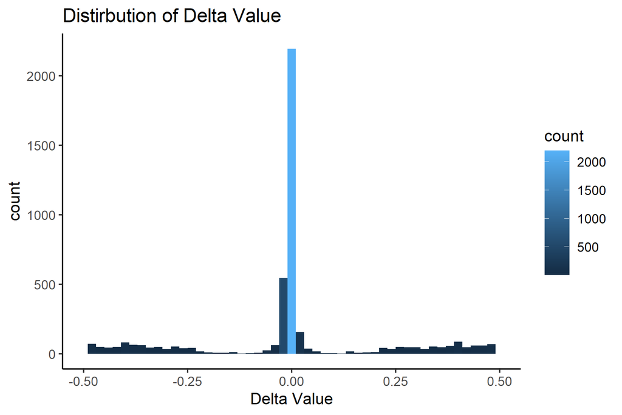

```r
#plot delta value where higher mem - lower mem
choice.memvalue =  choice %>%  mutate(value.highmem = case_when(mem_left >= mem_right ~ -delta.value, mem_left < mem_right ~ delta.value))
choice.memvalue =  choice.memvalue %>%  mutate(value.highmem = value.highmem/100)

g.deltaV = choice.memvalue %>% ggplot(aes(x = value.highmem, fill=..count..))+
  geom_histogram(binwidth = 0.02)+
  theme_classic()+
  ggtitle('Distirbution of Delta Value')+
  xlim(-0.5,0.5)+
  xlab('Delta Value')

ggsave('g.deltaV.png', height = 4, width = 6)
knitr::include_graphics("g.deltaV.png")
```

## Distribution of z-scored ratings by subject

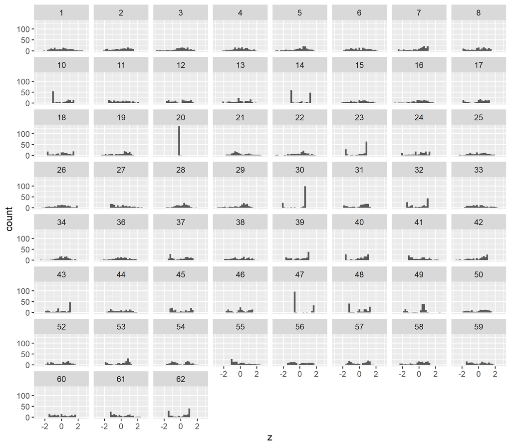

```r
#plot the distribution of z-scored values for each subject
rating = rating %>% dplyr::group_by(ID) %>% mutate(z = scale(as.numeric(response)))
#rating %>% dplyr::group_by(ID) %>% ggplot(aes(x = response, group = ID)) +
#  geom_histogram() +
#  facet_wrap(~ID)

#plot for z-scored individual ratings
g.rating = rating %>% dplyr::group_by(ID) %>% ggplot(aes(x = z, group = ID)) +
  geom_histogram() +
  facet_wrap(~ID) +
  xlim(-3, 3)

ggsave('g.rating.png', height = 7, width = 8)
knitr::include_graphics("g.rating.png")
```

# Model Fitting

### Model for choice behavior

```r
#mixted effects model for delta mem and delta value
#m1 = glmer(choseright~1+delta.mem*delta.value+(1+delta.mem*delta.value|ID), data = choice, family = "binomial")
#summary(m1)

#plot_model(m1, type = "pred")
```

### Model for RT

RT ~ delta.mem*absolute.delta.value.z with mixed effects Only z scored delta value able to predict RT, where higher value results in lower RT.

```r
## model for RT
choice = choice %>% mutate(abs.delta.v.z = abs(z.delta.value))
m2 = lmer(log(rt)~1+abs(delta.mem)*abs.delta.v.z+(1+abs(delta.mem)*abs.delta.v.z|ID),
           data = choice)
```

```
## boundary (singular) fit: see ?isSingular
```

```r
summary(m2)
```

```
## Linear mixed model fit by REML ['lmerMod']
## Formula: log(rt) ~ 1 + abs(delta.mem) * abs.delta.v.z + (1 + abs(delta.mem) *
##     abs.delta.v.z | ID)
##    Data: choice
##
## REML criterion at convergence: 1201.6
##
## Scaled residuals:
##     Min      1Q  Median      3Q     Max
## -6.0326 -0.6273 -0.0635  0.6023  4.0803
##
## Random effects:
##  Groups   Name                         Variance Std.Dev. Corr
##  ID       (Intercept)                  0.030456 0.17452
##           abs(delta.mem)               0.014814 0.12171  -0.29
##           abs.delta.v.z                0.002741 0.05236  -0.48  0.91
##           abs(delta.mem):abs.delta.v.z 0.014516 0.12048   0.11 -0.24 -0.57
##  Residual                              0.068599 0.26191
## Number of obs: 6000, groups:  ID, 44
##
## Fixed effects:
##                               Estimate Std. Error t value
## (Intercept)                   7.154086   0.027454 260.580
## abs(delta.mem)               -0.033269   0.051921  -0.641
## abs.delta.v.z                -0.054993   0.011150  -4.932
## abs(delta.mem):abs.delta.v.z -0.003185   0.052368  -0.061
##
## Correlation of Fixed Effects:
##             (Intr) abs(.) abs...
## abs(dlt.mm) -0.307
## abs.dlt.v.z -0.473  0.601
## abs(d.):...  0.186 -0.662 -0.659
## optimizer (nloptwrap) convergence code: 0 (OK)
## boundary (singular) fit: see ?isSingular
```

```r
#confint(m3,method="Wald")
```

## Explore the averaged subjective value (ratings)

### Correlations between value and memorability for image/words

There’s significant correlation between averaged value and image memorability

```r
# correlation between rated value in word choices and image memorability
cor.test(x = values_mem$value, y = values_mem$Memorability)
```

```
##
##  Pearson's product-moment correlation
##
## data:  values_mem$value and values_mem$Memorability
## t = 2.1725, df = 134, p-value = 0.03158
## alternative hypothesis: true correlation is not equal to 0
## 95 percent confidence interval:
##  0.01663595 0.34216128
## sample estimates:
##       cor
## 0.1844523
```

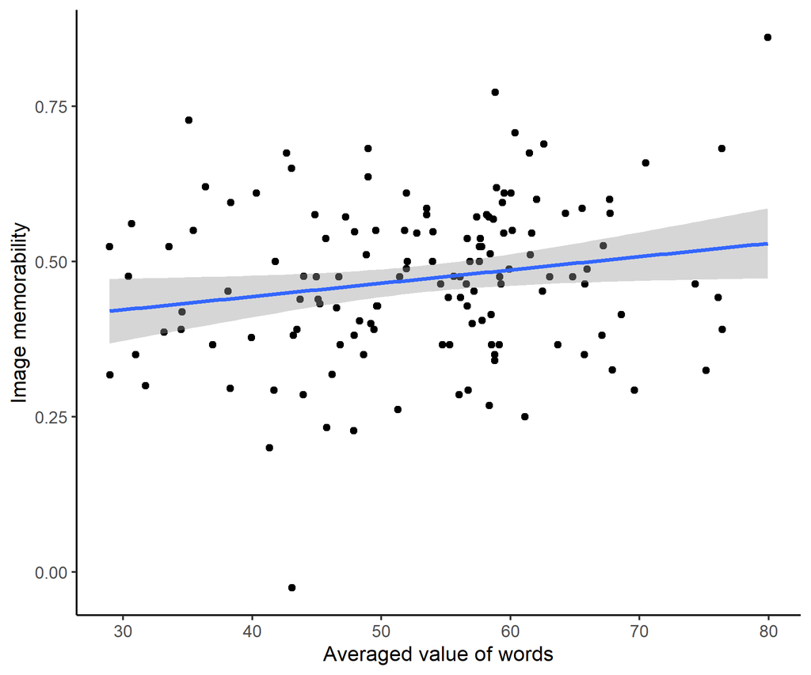

```r
# plot the correlation
p.scatter.value.mem = values_mem %>% ggplot(aes(x = value, y = Memorability)) +
  geom_point() +
  geom_smooth(method = 'lm') +
  xlab("Averaged value of words")+
  ylab("Image memorability") +
  theme_classic()

ggsave('p.scatter.value.mem.png', height = 5, width = 6)
knitr::include_graphics("p.scatter.value.mem.png")
```

However, there is no correlation between word memorability and averaged word values

```r
# correlation between rated value in word choices and word memorability
cor.test(x = values_mem$value, y = values_mem$word.mem)
```

```
##
##  Pearson's product-moment correlation
##
## data:  values_mem$value and values_mem$word.mem
## t = 0.62212, df = 134, p-value = 0.5349
## alternative hypothesis: true correlation is not equal to 0
## 95 percent confidence interval:
##  -0.1157127  0.2200108
## sample estimates:
##        cor
## 0.05366546
```

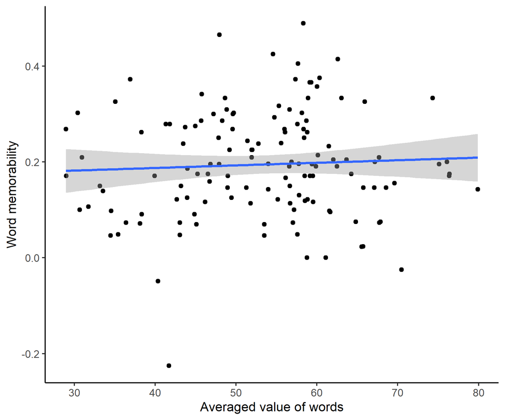

```r
# plot the correlation
p.scatter.value.word = values_mem %>% ggplot(aes(x = value, y = word.mem)) +
  geom_point() +
  geom_smooth(method = 'lm') +
  xlab("Averaged value of words")+
  ylab("Word memorability") +
  theme_classic()

ggsave('p.scatter.value.word.png', height = 5, width = 6)
knitr::include_graphics("p.scatter.value.word.png")
```

### Value and word length

No correlation between values and word length

```r
values_mem <- values_mem %>% mutate(length = nchar(word))
# correlation between rated value in word choices and word length
cor.test(x = values_mem$value, y = values_mem$length)
```

```
##
##  Pearson's product-moment correlation
##
## data:  values_mem$value and values_mem$length
## t = 0.1662, df = 134, p-value = 0.8682
## alternative hypothesis: true correlation is not equal to 0
## 95 percent confidence interval:
##  -0.1543496  0.1822487
## sample estimates:
##        cor
## 0.01435628
```

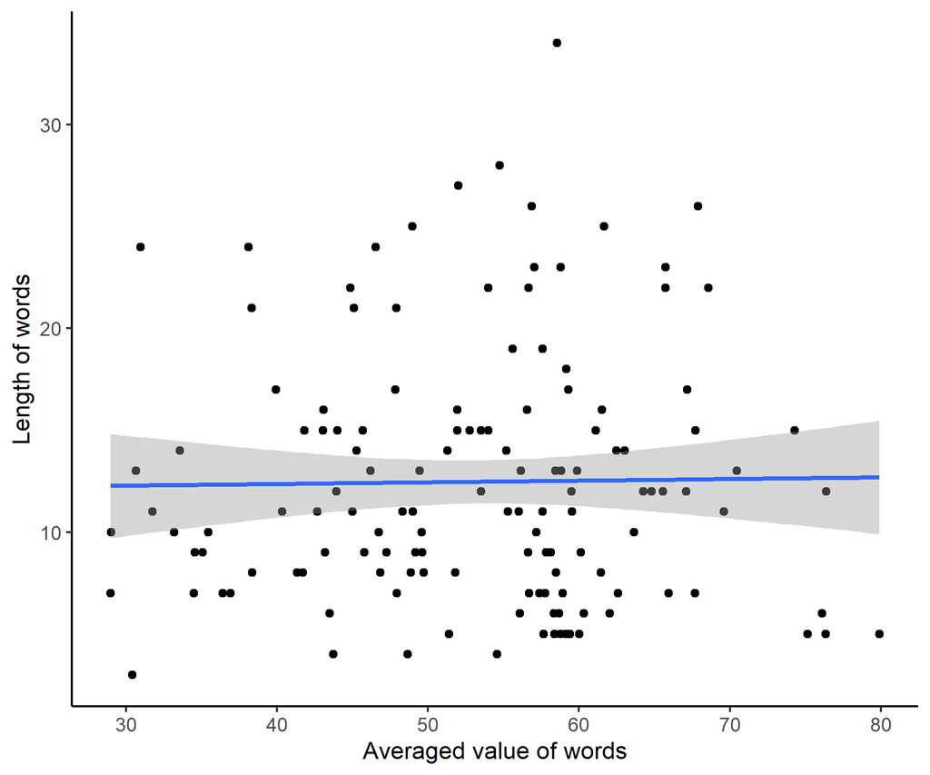

```r
# plot the correlation
p.scatter.value.length = values_mem %>% ggplot(aes(x = value, y = length)) +
  geom_point() +
  geom_smooth(method = 'lm') +
  xlab("Averaged value of words")+
  ylab("Length of words") +
  theme_classic()

ggsave('p.scatter.value.length.png', height = 5, width = 6)
knitr::include_graphics("p.scatter.value.length.png")
```

## Image mem and word choices

There’s a significant positive relation between word choices and image memorability, even after the value of words are controlled. `How to understand this result?`

```r
## Try to calculate image mem and choice behavior
choice.im = merge(choice, mem[c('food.item.e', 'Memorability')], by.x = "stim_left", by.y = "food.item.e") %>% rename(image.m.l = Memorability)
choice.im = merge(choice.im, mem[c('food.item.e', 'Memorability')], by.x = "stim_right", by.y = "food.item.e") %>% rename(image.m.r = Memorability) %>% mutate(delta.im.mem = image.m.r - image.m.l)

#mixted effects model for delta mem and delta value
# m3 = glmer(choseright~1+delta.im.mem*delta.value+(1+delta.im.mem*delta.value|ID), data = choice.im, family = "binomial")
# summary(m3)
#
# save(m3, file="C:/Users/Christine/Box Sync/data/mem_dm/model/m3_imagemem_wordvalue.RData")

load("C:/Users/Christine/Box Sync/data/mem_dm/model/m3_imagemem_wordvalue.RData")
summary(m3)
```

```
## Generalized linear mixed model fit by maximum likelihood (Laplace
##   Approximation) [glmerMod]
##  Family: binomial  ( logit )
## Formula: choseright ~ 1 + delta.im.mem * delta.value + (1 + delta.im.mem *
##     delta.value | ID)
##    Data: choice.im
##
##      AIC      BIC   logLik deviance df.resid
##   5901.7   5995.1  -2936.9   5873.7     5812
##
## Scaled residuals:
##     Min      1Q  Median      3Q     Max
## -8.1295 -0.8675 -0.0957  0.9209  8.6171
##
## Random effects:
##  Groups Name                     Variance  Std.Dev. Corr
##  ID     (Intercept)              0.0234904 0.15327
##         delta.im.mem             0.6404401 0.80028  -0.24
##         delta.value              0.0005565 0.02359  -0.32 -0.10
##         delta.im.mem:delta.value 0.0002045 0.01430   0.79  0.21 -0.74
## Number of obs: 5826, groups:  ID, 44
##
## Fixed effects:
##                           Estimate Std. Error z value Pr(>|z|)
## (Intercept)              -0.106299   0.039740  -2.675  0.00748 **
## delta.im.mem              0.539496   0.215213   2.507  0.01218 *
## delta.value               0.053968   0.004057  13.303  < 2e-16 ***
## delta.im.mem:delta.value -0.012817   0.010322  -1.242  0.21434
## ---
## Signif. codes:  0 '***' 0.001 '**' 0.01 '*' 0.05 '.' 0.1 ' ' 1
##
## Correlation of Fixed Effects:
##             (Intr) dlt.m. dlt.vl
## delta.im.mm -0.090
## delta.value -0.179 -0.052
## dlt.m.mm:d.  0.091  0.012 -0.170
## optimizer (Nelder_Mead) convergence code: 0 (OK)
## boundary (singular) fit: see ?isSingular
```

```
## Data were 'prettified'. Consider using `terms="delta.im.mem [all]"` to get smooth plots.
```

```
## Data were 'prettified'. Consider using `terms="delta.value [all]"` to get smooth plots.
```

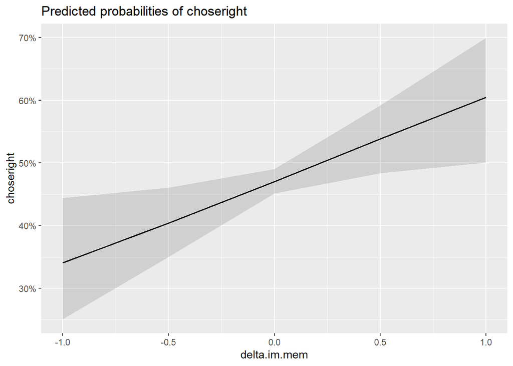

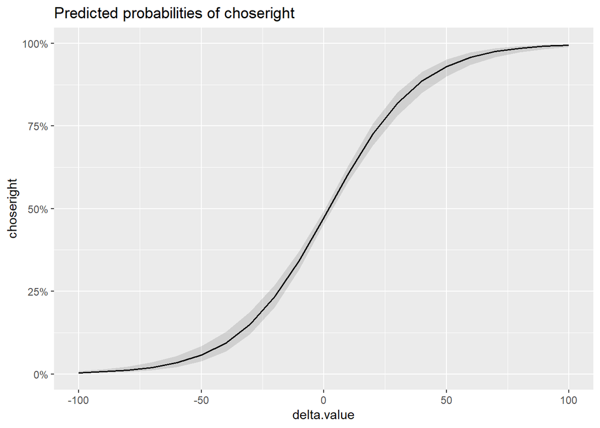

```r
plot_model(m3, type = "pred")
```

## Run Regression model with full sample (N = 56)

Run multiple regression model of choice ~ delta_value + delta_mem with the the sample of 56 participants (after filtering them based on RT and left/right bias)

Did not find significant relation between word memorability and choice behavior

```r
# run analysis with full sample
# the model with interaction is overfitted, therefore only puts single effects here

# m4 = glmer(choseright~1+delta.mem+delta.value+(1+delta.mem+delta.value|ID),
#            data = choice.full,
#            family = "binomial",
#            glmerControl(optimizer = "bobyqa", optCtrl = list(maxfun = 100000)))
#
# save(m4, file="C:/Users/Christine/Box Sync/data/mem_dm/model/m4_full.RData")

load("C:/Users/Christine/Box Sync/data/mem_dm/model/m4_full.RData")
summary(m4)
```

```
## Generalized linear mixed model fit by maximum likelihood (Laplace
##   Approximation) [glmerMod]
##  Family: binomial  ( logit )
## Formula:
## choseright ~ 1 + delta.mem + delta.value + (1 + delta.mem + delta.value |
##     ID)
##    Data: choice.full
## Control: glmerControl(optimizer = "bobyqa", optCtrl = list(maxfun = 1e+05))
##
##      AIC      BIC   logLik deviance df.resid
##   8264.6   8326.9  -4123.3   8246.6     7530
##
## Scaled residuals:
##     Min      1Q  Median      3Q     Max
## -8.1293 -0.9253 -0.0981  0.9865  8.1325
##
## Random effects:
##  Groups Name        Variance  Std.Dev. Corr
##  ID     (Intercept) 0.0181822 0.1348
##         delta.mem   0.0122572 0.1107   -0.23
##         delta.value 0.0008942 0.0299   -0.49  0.96
## Number of obs: 7539, groups:  ID, 56
##
## Fixed effects:
##             Estimate Std. Error z value Pr(>|z|)
## (Intercept) -0.08351    0.03258  -2.563   0.0104 *
## delta.mem   -0.08109    0.16799  -0.483   0.6293
## delta.value  0.04429    0.00432  10.253   <2e-16 ***
## ---
## Signif. codes:  0 '***' 0.001 '**' 0.01 '*' 0.05 '.' 0.1 ' ' 1
##
## Correlation of Fixed Effects:
##             (Intr) dlt.mm
## delta.mem   -0.015
## delta.value -0.256  0.077
## optimizer (bobyqa) convergence code: 0 (OK)
## boundary (singular) fit: see ?isSingular
```

```
## Data were 'prettified'. Consider using `terms="delta.mem [all]"` to get smooth plots.
```

```
## Data were 'prettified'. Consider using `terms="delta.value [all]"` to get smooth plots.
```

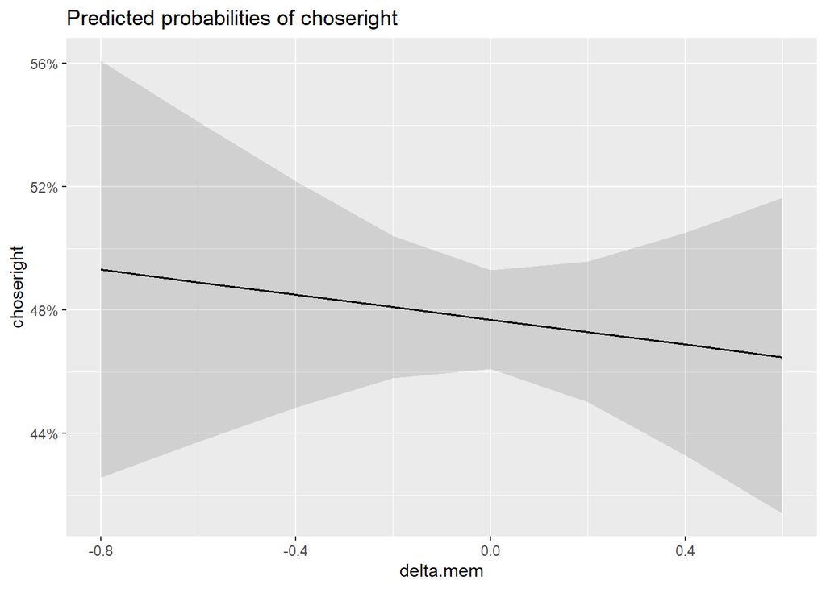

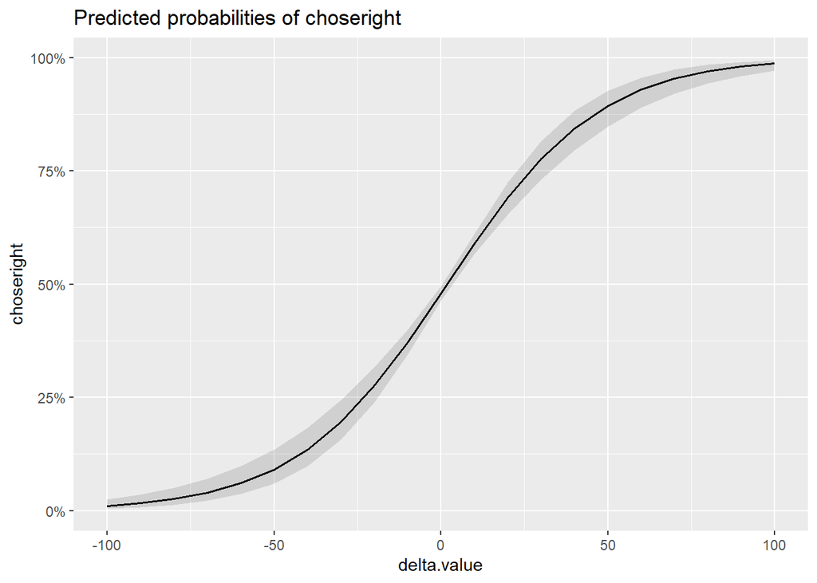

```r
plot_model(m4, type = "pred")
```

# Representative Data

## Distribution (N = 40)

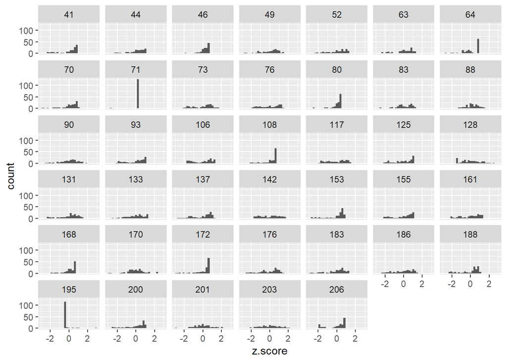

```r
# Distribution for individuals
rep <- read.csv("C:/Users/Christine/Box Sync/data/word_mem/rep/rep-task.csv")
rep <- rep %>% filter(ttype == "rep_rating")
rep <- rep %>% dplyr::group_by(run_id) %>% dplyr::mutate(z.score = scale(as.numeric(response)))

g.dis = rep %>% dplyr::group_by(run_id) %>% ggplot(aes(x = z.score, group = run_id)) +
  geom_histogram() +
  facet_wrap(~run_id) +
  xlim(-3, 3)
g.dis
```

## Averaged data for each image

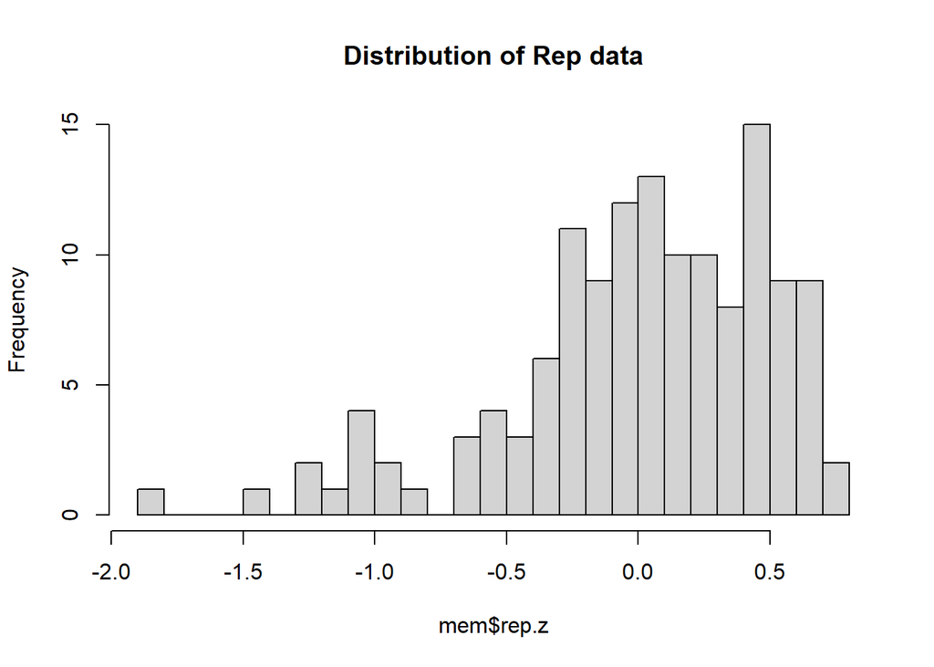

```r
  hist(mem$rep.z, breaks = 20, main = paste("Distribution of Rep data"))
```